# m15_bhv_202109_lme_rndint_2fac_naomit_inv

# Morph 15 Behavioral Data Analysed via Linear Mixed Effects Model

These data are from subjects 8-31 (25 subjects) of the Morph15 Suffix productivity Project. The data were collected between 3/25/2015 and 25/9/2015 using E-Prime. The E-Primes files used were “Morph15Group1Correct” and “Morph15Group2Correct”. The excel file exported from E-data Aid is ‘m15_bhv_25’

The stimuli are read in from ‘m15_stm_frq.csv’.

# Load Packages

```r
library(knitr)
library(markdown)
library(readr)
library(ez)
library(lme4)
library(stringr)
library(ggplot2)
library(dplyr)
library(tidyr)
library(gridExtra)
library(RColorBrewer)
```

## Define Standard error of the Mean Function

```r
sem = function(x)
  {
  sqrt(var(x)/length(x))
  }
```

# Read in Data and Format Data

This chunk reads the dataset in long format into an R dataframe using the read.csv(file) function.

The stimuli are read in from “m15_stm_frq.csv”. This file contains stimuli divided into high and low parsability on the basis of affix frequency (afx_frq), relative frequency determined via a median split based on the **stem frequency to whole-word frequency ratio** (med_splt) and relative frequency determined via a a split based on whether the **stem frequency to whole-word frequency ratio** is greater than 1 or less than 1 (ratio_splt).

8/1/2021 New version of the analysis adds another split based on whether the stem to whole-word frequency is greater or less then 1.5.

** In order to read in files, remember to ’set working directory to project directory""

```r
library(readr)
m15_bhv <- read_csv("M15_ALL_SUBJS_BHV_DATA_orig-3.csv")
frq <- read_csv("stimuli/m15_stm_frq_rel_subset.csv")
m15_bhv <- m15_bhv %>% mutate(Subject = replace(Subject, Subject == 241, 24)) # changes subj 241 to 24
```

This chunk changes removes extraneous digits from column names and makes them all lowercase, renames cols with `.x` after their name and removes `rel` column from freq dataframe

```r
names(m15_bhv) <- tolower(names(m15_bhv))
names(frq) <- tolower(names(frq))

frq <- rename(frq, stemid = trigger)
frq <- rename (frq, prime = prime.x)
frq <- rename (frq, stem = stem.x)
frq$rel <- NULL
```

This chunk creates a separate dataframe for the words

```r
m15_bhv_words<-filter(m15_bhv,correct_response == 6)
m15_bhv_words$relatedness <- ifelse(m15_bhv_words$trigger <= 100, "related", "unrelated")
```

We now combine the stimulus df with the data df

```r
m15_bhv_frq_words <- left_join(m15_bhv_words, frq, by = "stemid")
# m15_bhv_frq_word <- dplyr::select(m15_bhv_frq_words, subject, prime, target, stem.x, stemid, relatedness, afx_frq, med_splt, target.acc, target.rt)

write.csv(m15_bhv_frq_words, "m15_bhv_frq_words.csv")
```

# Replaces NA rt values with the mean for the dataset in column new.rt. Also creates new dataframe (m15_bhv_frq_words_na.omit) with just the non-missing data

```r
m15_bhv_frq_words$new.rt<- replace_na(m15_bhv_frq_words$target.rt.trm.err,
                                                 mean(m15_bhv_frq_words$target.rt.trm.err,
                                                      na.rm=TRUE ))
missing_data<- filter(m15_bhv_frq_words, is.na(m15_bhv_frq_words$target.rt.trm.err))
m15_na.omit <- filter(m15_bhv_frq_words, !is.na(m15_bhv_frq_words$target.rt.trm.err))
xtab.missing.data <- xtabs(~relatedness+med_splt, data=missing_data)
m15_bhv_frq_words_rmna <-filter(m15_bhv_frq_words,!is.na(m15_bhv_frq_words$target.rt.trm.err))
```

This chunk creates two new dependent variables by doing a log transformation and an inverse transformation of the reaction times

```r
m15_bhv_frq_words_rmna$log.rt <- log(m15_bhv_frq_words_rmna$target.rt.trm.err)
m15_bhv_frq_words_rmna$inverse.rt <- (1/(m15_bhv_frq_words_rmna$target.rt.trm.err))*1000

write.csv(m15_bhv_frq_words_rmna, "m15_bhv_frq_words_rmna.csv")
```

# Inverse RT

## Condition Means: Inverse RT

`summarise()` creates a new data frame. It will have one (or more) rows for each combination of grouping variables; if there are no grouping variables, the output will have a single row summarising all observations in the input. It will contain one column for each grouping variable and one column for each of the summary statistics that you have specified.

## Barplots for Inverse RT

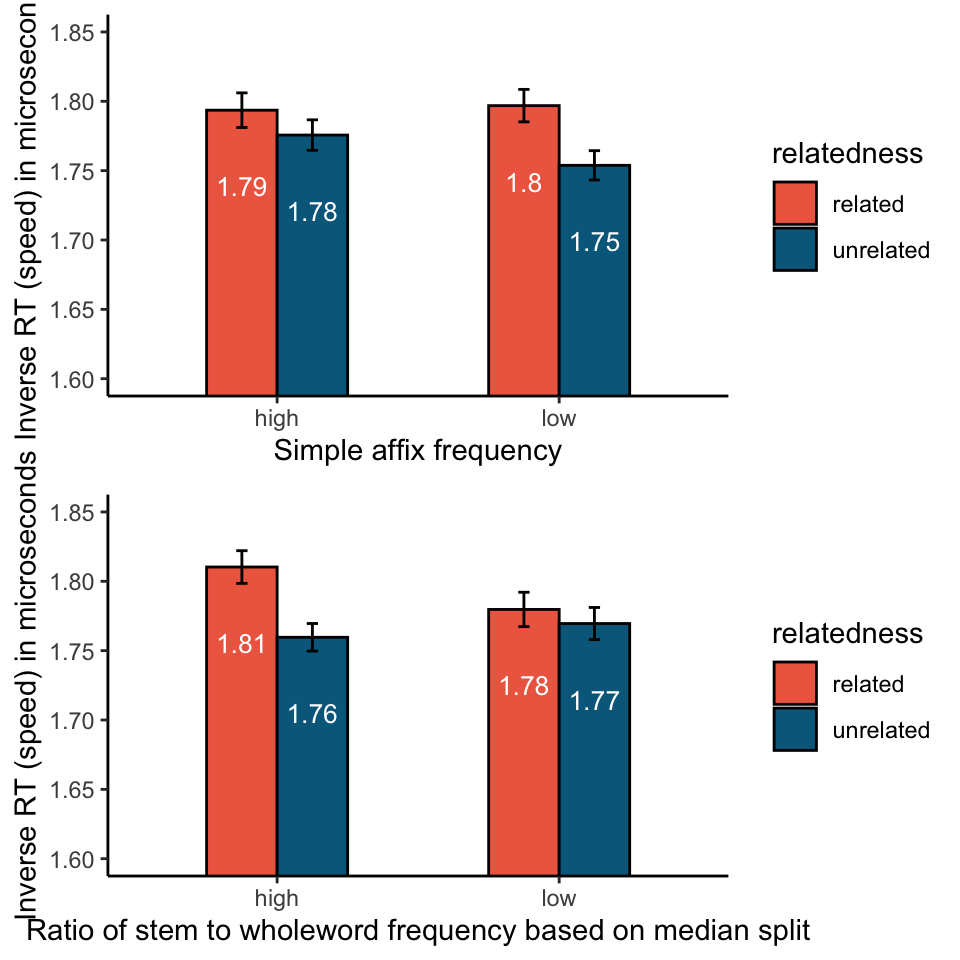

# Models

Reminder about goodness-of-fit criteria (from Wikipedia) Suppose that we have a statistical model of some data. Let k be the number of estimated parameters in the model. Let $\hat {L}$ be the maximum value of the likelihood function for the model, where ‘likelihood’ is used to describe the plausibility of a value for the parameter, given some data. The likelihood function answers the question *What is the probability of observing the current dataset, when I assume a given set of parameters for my linear model?* Considering only μ, the likelihood L or its natural logarithm (LogL) is maximum when $\sum_{i=1}^n ( y - \mu)^2$ is a minimum. Then the AIC value of the model is the following:

$AIC =2k-2\ln(\hat {L})$

Given a set of candidate models for the data, the preferred model is the one with the minimum AIC value. Thus, AIC rewards goodness of fit (as assessed by the likelihood function), but it also includes a penalty that is an increasing function of the number of estimated parameters.

From Petr Keil (http://www.petrkeil.com/?p=836) “Model selection is a process of seeking the model in a set of candidate models that gives the best balance between model fit and complexity (Burnham & Anderson 2002). I have always used AIC for that. But you can also do that by crossvalidation. Specifically, Stone (1977) showed that the AIC and leave-one out crossvalidation are asymptotically equivalent.” He also included the BIC (Bayesian Information Criterion) and found that all three are equivalent.

From (https://www.scribbr.com/statistics/akaike-information-criterion/) : If a model is more than 2 AIC units lower than another, then it is considered significantly better than that model.

# Inverse RT

## Run ANOVA Affix Frequency

### Null Model: Affix Frequency: Inverse RT

```r
afxfrq_inv_null.model = lmer(inverse.rt ~ 1 + (1|subject) + (1|stemid),
                             data= m15_bhv_frq_words_rmna, REML=FALSE)
summary(afxfrq_inv_null.model)
```

```
Linear mixed model fit by maximum likelihood  ['lmerMod']
Formula: inverse.rt ~ 1 + (1 | subject) + (1 | stemid)
   Data: m15_bhv_frq_words_rmna

     AIC      BIC   logLik deviance df.resid
  3085.7   3111.4  -1538.8   3077.7     4570

Scaled residuals:
    Min      1Q  Median      3Q     Max
-3.7210 -0.6352  0.0325  0.6270  6.7862

Random effects:
 Groups   Name        Variance Std.Dev.
 stemid   (Intercept) 0.01301  0.1141
 subject  (Intercept) 0.03130  0.1769
 Residual             0.10782  0.3284
Number of obs: 4574, groups:  stemid, 100; subject, 25

Fixed effects:
            Estimate Std. Error t value
(Intercept)   1.7687     0.0375   47.17
```

### Main Effects Model: Affix Frequency: Inverse RT

This model of the Inverse RT data contains fixed intercepts for *affix frequency* and *relatedness* as well as random intercepts for subjects and items (adjustments to the mean for each subject and item)

```r
afxfrq_inv_main.model = lmer(inverse.rt ~ afx_frq + relatedness + (1|subject) + (1|stemid),
                             data= m15_bhv_frq_words_rmna, REML=FALSE)
summary(afxfrq_inv_main.model)
```

```
Linear mixed model fit by maximum likelihood  ['lmerMod']
Formula: inverse.rt ~ afx_frq + relatedness + (1 | subject) + (1 | stemid)
   Data: m15_bhv_frq_words_rmna

     AIC      BIC   logLik deviance df.resid
  3078.9   3117.5  -1533.4   3066.9     4568

Scaled residuals:
    Min      1Q  Median      3Q     Max
-3.6801 -0.6222  0.0372  0.6364  6.7459

Random effects:
 Groups   Name        Variance Std.Dev.
 stemid   (Intercept) 0.01303  0.1142
 subject  (Intercept) 0.03131  0.1770
 Residual             0.10756  0.3280
Number of obs: 4574, groups:  stemid, 100; subject, 25

Fixed effects:
                      Estimate Std. Error t value
(Intercept)           1.785736   0.039835  44.828
afx_frqlow           -0.001881   0.024842  -0.076
relatednessunrelated -0.031853   0.009708  -3.281

Correlation of Fixed Effects:
            (Intr) afx_fr
afx_frqlow  -0.314
rltdnssnrlt -0.123  0.001
```

### Interaction Model: Affix Frequency: Inverse RT

```r
afxfrq_inv_inter.model = lmer(inverse.rt ~ afx_frq * relatedness + (1|subject) + (1|stemid),
                              data= m15_bhv_frq_words_rmna, REML=FALSE)
summary(afxfrq_inv_inter.model)
```

```
Linear mixed model fit by maximum likelihood  ['lmerMod']
Formula: inverse.rt ~ afx_frq * relatedness + (1 | subject) + (1 | stemid)
   Data: m15_bhv_frq_words_rmna

     AIC      BIC   logLik deviance df.resid
  3079.0   3124.0  -1532.5   3065.0     4567

Scaled residuals:
    Min      1Q  Median      3Q     Max
-3.7010 -0.6240  0.0372  0.6357  6.7682

Random effects:
 Groups   Name        Variance Std.Dev.
 stemid   (Intercept) 0.01306  0.1143
 subject  (Intercept) 0.03130  0.1769
 Residual             0.10751  0.3279
Number of obs: 4574, groups:  stemid, 100; subject, 25

Fixed effects:
                                Estimate Std. Error t value
(Intercept)                      1.77877    0.04015  44.304
afx_frqlow                       0.01171    0.02672   0.438
relatednessunrelated            -0.01809    0.01387  -1.304
afx_frqlow:relatednessunrelated -0.02695    0.01941  -1.388

Correlation of Fixed Effects:
            (Intr) afx_fr rltdns
afx_frqlow  -0.335
rltdnssnrlt -0.175  0.263
afx_frqlw:r  0.125 -0.366 -0.715
```

### Compare Null and Main Models: Affix Frequency

```r
anova(afxfrq_inv_null.model,afxfrq_inv_main.model)
```

```
Data: m15_bhv_frq_words_rmna
Models:
afxfrq_inv_null.model: inverse.rt ~ 1 + (1 | subject) + (1 | stemid)
afxfrq_inv_main.model: inverse.rt ~ afx_frq + relatedness + (1 | subject) + (1 | stemid)
                      npar    AIC    BIC  logLik deviance  Chisq Df Pr(>Chisq)
afxfrq_inv_null.model    4 3085.7 3111.4 -1538.8   3077.7
afxfrq_inv_main.model    6 3078.9 3117.5 -1533.5   3066.9 10.758  2   0.004612

afxfrq_inv_null.model
afxfrq_inv_main.model **
---
Signif. codes:  0 '***' 0.001 '**' 0.01 '*' 0.05 '.' 0.1 ' ' 1
```

### Compare Main and Interaction Models: Affix Frequency

```r
anova(afxfrq_inv_main.model,afxfrq_inv_inter.model)
```

```
Data: m15_bhv_frq_words_rmna
Models:
afxfrq_inv_main.model: inverse.rt ~ afx_frq + relatedness + (1 | subject) + (1 | stemid)
afxfrq_inv_inter.model: inverse.rt ~ afx_frq * relatedness + (1 | subject) + (1 | stemid)
                       npar    AIC    BIC  logLik deviance Chisq Df Pr(>Chisq)
afxfrq_inv_main.model     6 3078.9 3117.5 -1533.5   3066.9
afxfrq_inv_inter.model    7 3079.0 3124.0 -1532.5   3065.0 1.926  1     0.1652
```

## Run ANOVA Median Split

### Null Model: Median Split: Inverse RT

```r
medsplt_inv_null.model = lmer(inverse.rt ~ 1 + (1|subject) + (1|stemid),
                             data= m15_bhv_frq_words_rmna, REML=FALSE)
summary(medsplt_inv_null.model)
```

```
Linear mixed model fit by maximum likelihood  ['lmerMod']
Formula: inverse.rt ~ 1 + (1 | subject) + (1 | stemid)
   Data: m15_bhv_frq_words_rmna

     AIC      BIC   logLik deviance df.resid
  3085.7   3111.4  -1538.8   3077.7     4570

Scaled residuals:
    Min      1Q  Median      3Q     Max
-3.7210 -0.6352  0.0325  0.6270  6.7862

Random effects:
 Groups   Name        Variance Std.Dev.
 stemid   (Intercept) 0.01301  0.1141
 subject  (Intercept) 0.03130  0.1769
 Residual             0.10782  0.3284
Number of obs: 4574, groups:  stemid, 100; subject, 25

Fixed effects:
            Estimate Std. Error t value
(Intercept)   1.7687     0.0375   47.17
```

### Main Effects Model: Median Split: Inverse RT

```r
medsplt_inv_main.model = lmer(inverse.rt ~ med_splt + relatedness + (1|subject) + (1|stemid),
                              data= m15_bhv_frq_words_rmna,REML=FALSE)
summary(medsplt_inv_main.model)
```

```
Linear mixed model fit by maximum likelihood  ['lmerMod']
Formula: inverse.rt ~ med_splt + relatedness + (1 | subject) + (1 | stemid)
   Data: m15_bhv_frq_words_rmna

     AIC      BIC   logLik deviance df.resid
  3078.6   3117.2  -1533.3   3066.6     4568

Scaled residuals:
    Min      1Q  Median      3Q     Max
-3.6827 -0.6215  0.0358  0.6339  6.7432

Random effects:
 Groups   Name        Variance Std.Dev.
 stemid   (Intercept) 0.01299  0.114
 subject  (Intercept) 0.03132  0.177
 Residual             0.10756  0.328
Number of obs: 4574, groups:  stemid, 100; subject, 25

Fixed effects:
                      Estimate Std. Error t value
(Intercept)           1.791644   0.039792  45.025
med_spltlow          -0.013733   0.024806  -0.554
relatednessunrelated -0.031841   0.009708  -3.280

Correlation of Fixed Effects:
            (Intr) md_spl
med_spltlow -0.311
rltdnssnrlt -0.122 -0.002
```

### Interaction Model: Median Split: Inverse RT

```r
medsplt_inv_inter.model = lmer(inverse.rt ~ med_splt * relatedness + (1|subject) + (1|stemid),
                               data= m15_bhv_frq_words_rmna,REML=FALSE)
summary(medsplt_inv_inter.model)
```

```
Linear mixed model fit by maximum likelihood  ['lmerMod']
Formula: inverse.rt ~ med_splt * relatedness + (1 | subject) + (1 | stemid)
   Data: m15_bhv_frq_words_rmna

     AIC      BIC   logLik deviance df.resid
  3076.2   3121.1  -1531.1   3062.2     4567

Scaled residuals:
    Min      1Q  Median      3Q     Max
-3.6547 -0.6239  0.0428  0.6259  6.7147

Random effects:
 Groups   Name        Variance Std.Dev.
 stemid   (Intercept) 0.01300  0.1140
 subject  (Intercept) 0.03131  0.1770
 Residual             0.10745  0.3278
Number of obs: 4574, groups:  stemid, 100; subject, 25

Fixed effects:
                                 Estimate Std. Error t value
(Intercept)                       1.80176    0.04008  44.952
med_spltlow                      -0.03437    0.02668  -1.289
relatednessunrelated             -0.05201    0.01362  -3.818
med_spltlow:relatednessunrelated  0.04093    0.01941   2.109

Correlation of Fixed Effects:
            (Intr) md_spl rltdns
med_spltlow -0.331
rltdnssnrlt -0.171  0.256
md_spltlw:r  0.120 -0.367 -0.702
```

### Compare Null and Main Models: Median Split

```r
anova(medsplt_inv_null.model,medsplt_inv_main.model)
```

```
Data: m15_bhv_frq_words_rmna
Models:
medsplt_inv_null.model: inverse.rt ~ 1 + (1 | subject) + (1 | stemid)
medsplt_inv_main.model: inverse.rt ~ med_splt + relatedness + (1 | subject) + (1 | stemid)
                       npar    AIC    BIC  logLik deviance  Chisq Df Pr(>Chisq)
medsplt_inv_null.model    4 3085.7 3111.4 -1538.8   3077.7
medsplt_inv_main.model    6 3078.6 3117.2 -1533.3   3066.6 11.059  2   0.003969

medsplt_inv_null.model
medsplt_inv_main.model **
---
Signif. codes:  0 '***' 0.001 '**' 0.01 '*' 0.05 '.' 0.1 ' ' 1
```

### Compare Main and Interaction Models: Median Split

```r
anova(medsplt_inv_main.model,medsplt_inv_inter.model)
```

```
Data: m15_bhv_frq_words_rmna
Models:
medsplt_inv_main.model: inverse.rt ~ med_splt + relatedness + (1 | subject) + (1 | stemid)
medsplt_inv_inter.model: inverse.rt ~ med_splt * relatedness + (1 | subject) + (1 | stemid)
                        npar    AIC    BIC  logLik deviance  Chisq Df
medsplt_inv_main.model     6 3078.6 3117.2 -1533.3   3066.6
medsplt_inv_inter.model    7 3076.2 3121.2 -1531.1   3062.2 4.4464  1
                        Pr(>Chisq)
medsplt_inv_main.model
medsplt_inv_inter.model    0.03497 *
---
Signif. codes:  0 '***' 0.001 '**' 0.01 '*' 0.05 '.' 0.1 ' ' 1
```

# Compare models using AIC

```r
library(AICcmodavg)
afxfrq_models <- list(afxfrq_inv_null.model, afxfrq_inv_main.model, afxfrq_inv_inter.model)
medsplt_models <- list(medsplt_inv_null.model, medsplt_inv_main.model, medsplt_inv_inter.model)
model.names <- c('null.mod', 'maineffects.mod', 'interaction.mod')

aictab(cand.set = afxfrq_models, modnames = model.names)
```

```
Model selection based on AICc:

                K    AICc Delta_AICc AICcWt Cum.Wt       LL
maineffects.mod 6 3078.92       0.00   0.50   0.50 -1533.45
interaction.mod 7 3079.00       0.08   0.48   0.98 -1532.49
null.mod        4 3085.66       6.75   0.02   1.00 -1538.83
```

```r
aictab(cand.set = medsplt_models, modnames = model.names)
```

```
Model selection based on AICc:

                K    AICc Delta_AICc AICcWt Cum.Wt       LL
interaction.mod 7 3076.18       0.00   0.77   0.77 -1531.08
maineffects.mod 6 3078.62       2.44   0.23   0.99 -1533.30
null.mod        4 3085.66       9.49   0.01   1.00 -1538.83
```